# Week 6 - Analysis of longitudinal data

## Part 1 - Implement the analyses of Chapter 8 of MABS using the RATS data.

Read the data:

```r
library(dplyr)
```

```r
library(tidyr)
library(ggplot2)
library(lme4)
library(GGally)
library(ggplot2)
RATS <- read.csv(file = "~/IODS-project/data/RATS.csv", header = TRUE, row.names = 1)
str(RATS)
```

```
## 'data.frame':    176 obs. of  5 variables:
##  $ ID    : int  1 2 3 4 5 6 7 8 9 10 ...
##  $ Group : int  1 1 1 1 1 1 1 1 2 2 ...
##  $ WD    : Factor w/ 11 levels "WD1","WD15","WD22",..: 1 1 1 1 1 1 1 1 1 1 ...
##  $ weight: int  240 225 245 260 255 260 275 245 410 405 ...
##  $ Time  : int  1 1 1 1 1 1 1 1 1 1 ...
```

Factor the categorical variables:

```r
RATS$ID <- factor(RATS$ID)
RATS$Group <- factor(RATS$Group)
str(RATS)
```

```
## 'data.frame':    176 obs. of  5 variables:
##  $ ID    : Factor w/ 16 levels "1","2","3","4",..: 1 2 3 4 5 6 7 8 9 10 ...
##  $ Group : Factor w/ 3 levels "1","2","3": 1 1 1 1 1 1 1 1 2 2 ...
##  $ WD    : Factor w/ 11 levels "WD1","WD15","WD22",..: 1 1 1 1 1 1 1 1 1 1 ...
##  $ weight: int  240 225 245 260 255 260 275 245 410 405 ...
##  $ Time  : int  1 1 1 1 1 1 1 1 1 1 ...
```

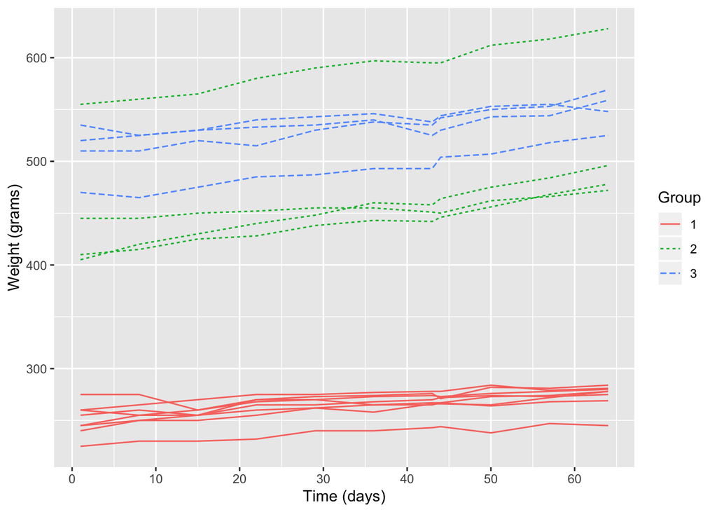

```r
ggplot(RATS, aes(x = Time, y = weight, color=Group, group = ID)) +
  geom_line(aes(linetype = Group)) +
  scale_x_continuous(name = "Time (days)", breaks = seq(0, 60, 10)) +
  scale_y_continuous(name = "Weight (grams)")
```

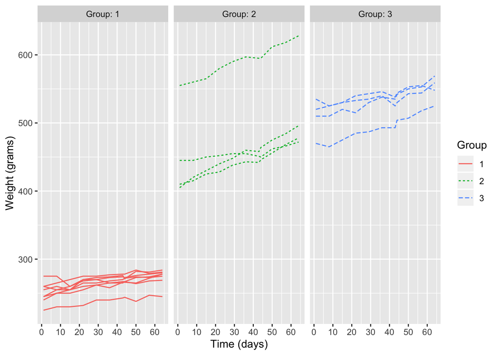

```r
ggplot(RATS, aes(x = Time, y = weight, color=Group, group = ID)) +
  geom_line(aes(linetype = Group)) +
  scale_x_continuous(name = "Time (days)", breaks = seq(0, 60, 10)) +
  scale_y_continuous(name = "Weight (grams)") +
  facet_grid(. ~ Group, labeller = label_both)
```

The graph shows the weight change of 3 groups of rats during the study which has a duration of 60 days. Looking at the graph, we can observe that the tendency to gain weight is higher for group 2 and 3 as compared to group 1.

Let’s standardize the variables

```r
library(ggplot2)
library(dplyr)
library(tidyr)
library(lme4)
RATS_1 <- RATS %>%
  group_by(Time) %>%
  mutate(stdrats = (weight - mean(weight))/sd(weight) ) %>%
  ungroup()
glimpse(RATS_1)
```

```
## Observations: 176
## Variables: 6
## $ ID      <fct> 1, 2, 3, 4, 5, 6, 7, 8, 9, 10, 11, 12, 13, 14, 15, 16, 1…
## $ Group   <fct> 1, 1, 1, 1, 1, 1, 1, 1, 2, 2, 2, 2, 3, 3, 3, 3, 1, 1, 1,…
## $ WD      <fct> WD1, WD1, WD1, WD1, WD1, WD1, WD1, WD1, WD1, WD1, WD1, W…
## $ weight  <int> 240, 225, 245, 260, 255, 260, 275, 245, 410, 405, 445, 5…
## $ Time    <int> 1, 1, 1, 1, 1, 1, 1, 1, 1, 1, 1, 1, 1, 1, 1, 1, 8, 8, 8,…
## $ stdrats <dbl> -1.0011429, -1.1203857, -0.9613953, -0.8421525, -0.88190…
```

Plot using the standardize data:

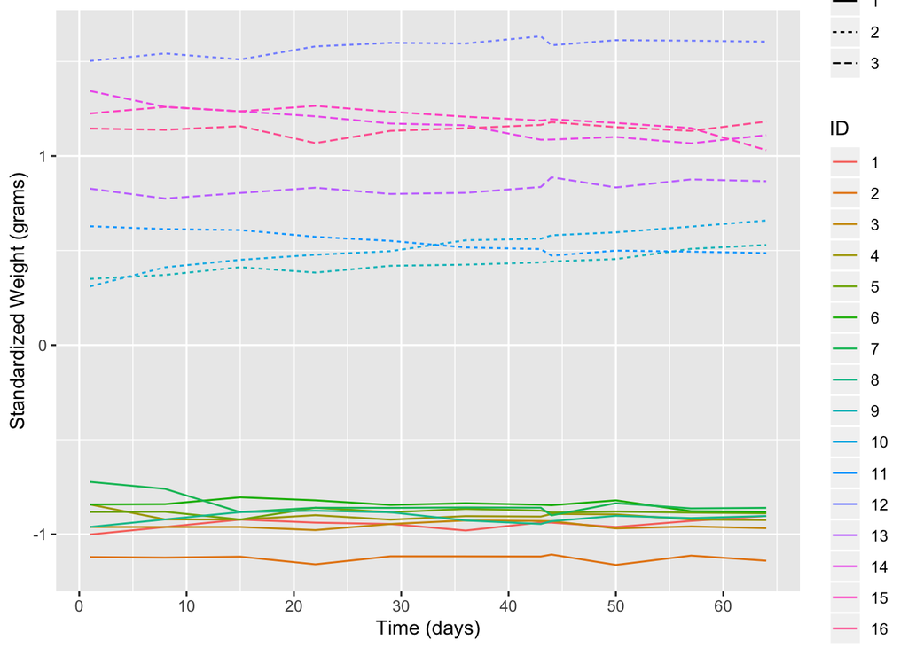

```r
ggplot(RATS_1, aes(x = Time, y = stdrats, color=ID, group = ID)) +
  geom_line(aes(linetype = Group)) +
  scale_x_continuous(name = "Time (days)", breaks = seq(0, 60, 10)) +
  scale_y_continuous(name = "Standardized Weight (grams)")
```

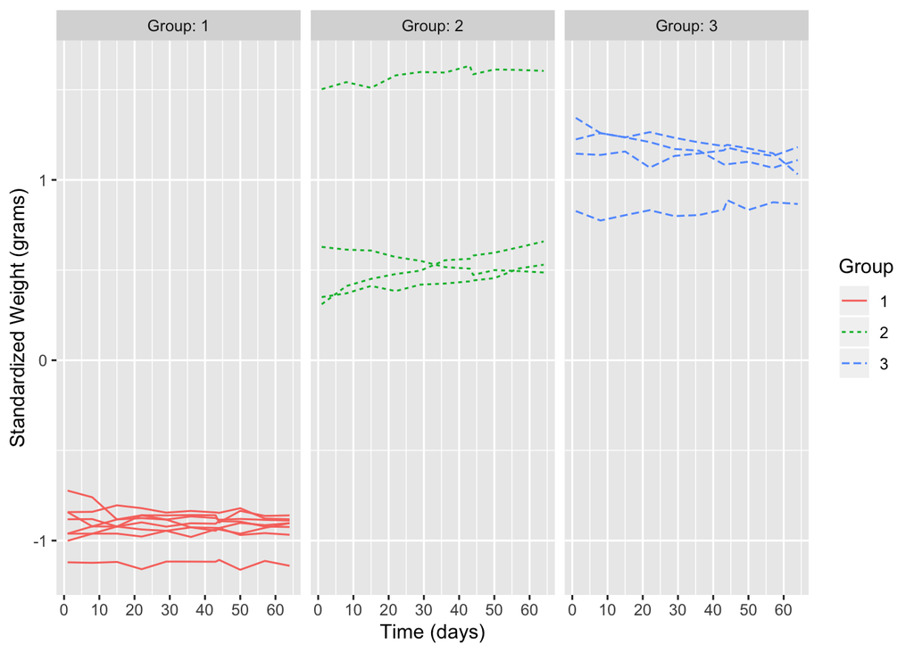

```r
ggplot(RATS_1, aes(x = Time, y = stdrats, color=Group, group = ID)) +
  geom_line(aes(linetype = Group)) +
  scale_x_continuous(name = "Time (days)", breaks = seq(0, 60, 10)) +
  scale_y_continuous(name = "Standardized Weight (grams)") +
  facet_grid(. ~ Group, labeller = label_both)
```

The mean profiles suggest there is a huge difference between the 3 groups with respect to mean weight.

Summary graph using means profiles:

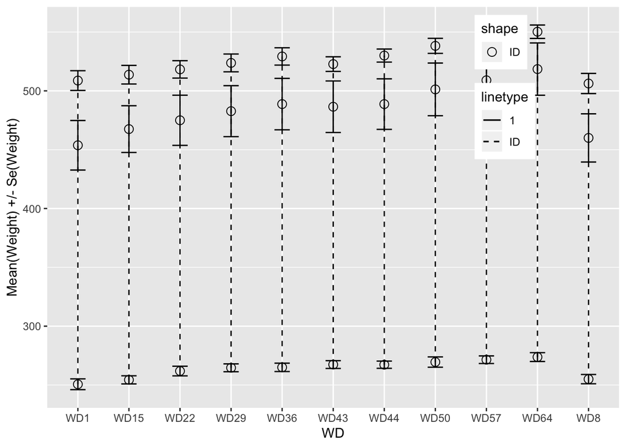

```r
n <- RATS$Time %>% unique() %>% length()
RATS_2 <- RATS_1 %>%
  group_by(Group, WD) %>%
  summarise( mean = mean(weight), se = sd(weight)/sqrt(n) ) %>%
  ungroup()
ggplot(RATS_2, aes(x = WD, y = mean, linetype = "ID", shape = "ID")) +
  geom_line() +
  scale_linetype_manual(values = c(1,2)) +
  geom_point(size=3) +
  scale_shape_manual(values = c(1,2)) +
  geom_errorbar(aes(ymin = mean - se, ymax = mean + se, linetype="1"), width=0.3) +
  theme(legend.position = c(0.8,0.8)) +
  scale_y_continuous(name = "Mean(Weight) +/- Se(Weight)")
```

We can also check the impact of outliers in the study.

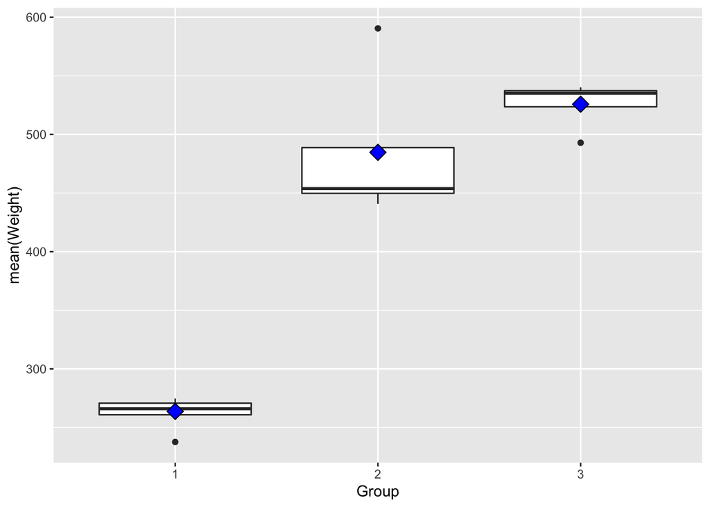

```r
RATS_3 <- RATS_1 %>%
  filter(Time > 0) %>%
  group_by(Group, ID) %>%
  summarise( mean=mean(weight) ) %>%
  ungroup()
ggplot(RATS_3, aes(x = Group, y = mean)) +
  geom_boxplot() +
  stat_summary(fun.y = "mean", geom = "point", shape=23, size=4, fill = "blue") +
  scale_y_continuous(name = "mean(Weight)")
```

There are outliers in data which can be seen clearly here. The most significant outlier can be found in group 2 which we can remove for better analysis.

```r
RATS_4 <- RATS_3 %>% filter(mean <570)
```

```r
oneway.test(mean~Group,data=RATS_4,var.equal=TRUE)
```

```
##
##  One-way analysis of means
##
## data:  mean and Group
## F = 483.6, num df = 2, denom df = 12, p-value = 3.387e-12
```

## Part 2 - Implement the analyses of Chapter 9 of MABS using the BPRS data.

Read the data:

```r
BPRS <- read.csv(file = "~/IODS-project/data/BPRS.csv", header = TRUE, row.names = 1)
str(BPRS)
```

```
## 'data.frame':    360 obs. of  5 variables:
##  $ treatment: int  1 1 1 1 1 1 1 1 1 1 ...
##  $ subject  : int  1 2 3 4 5 6 7 8 9 10 ...
##  $ weeks    : Factor w/ 9 levels "week0","week1",..: 1 1 1 1 1 1 1 1 1 1 ...
##  $ bprs     : int  42 58 54 55 72 48 71 30 41 57 ...
##  $ week     : int  0 0 0 0 0 0 0 0 0 0 ...
```

Factor the categorical variables and converting weeks from factor to char.

```r
BPRS$treatment <- factor(BPRS$treatment)
BPRS$subject <- factor(BPRS$subject)
BPRS$weeks <- as.character(BPRS$weeks)
str(BPRS)
```

```
## 'data.frame':    360 obs. of  5 variables:
##  $ treatment: Factor w/ 2 levels "1","2": 1 1 1 1 1 1 1 1 1 1 ...
##  $ subject  : Factor w/ 20 levels "1","2","3","4",..: 1 2 3 4 5 6 7 8 9 10 ...
##  $ weeks    : chr  "week0" "week0" "week0" "week0" ...
##  $ bprs     : int  42 58 54 55 72 48 71 30 41 57 ...
##  $ week     : int  0 0 0 0 0 0 0 0 0 0 ...
```

Standardize the data:

```r
BPRS <- BPRS %>%
  group_by(week) %>%
  mutate(stdbprs = (bprs - mean(bprs))/sd(bprs) ) %>%
  ungroup()
str(BPRS)
```

```
## Classes 'tbl_df', 'tbl' and 'data.frame':    360 obs. of  6 variables:
##  $ treatment: Factor w/ 2 levels "1","2": 1 1 1 1 1 1 1 1 1 1 ...
##  $ subject  : Factor w/ 20 levels "1","2","3","4",..: 1 2 3 4 5 6 7 8 9 10 ...
##  $ weeks    : chr  "week0" "week0" "week0" "week0" ...
##  $ bprs     : int  42 58 54 55 72 48 71 30 41 57 ...
##  $ week     : int  0 0 0 0 0 0 0 0 0 0 ...
##  $ stdbprs  : num  -0.425 0.708 0.425 0.495 1.698 ...
```

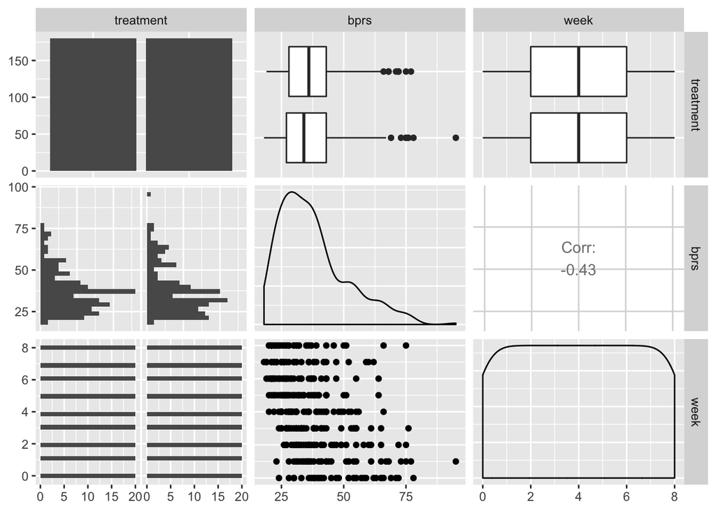

```r
ggpairs(BPRS[,c(1,4:5)])
```

Plotting the data:

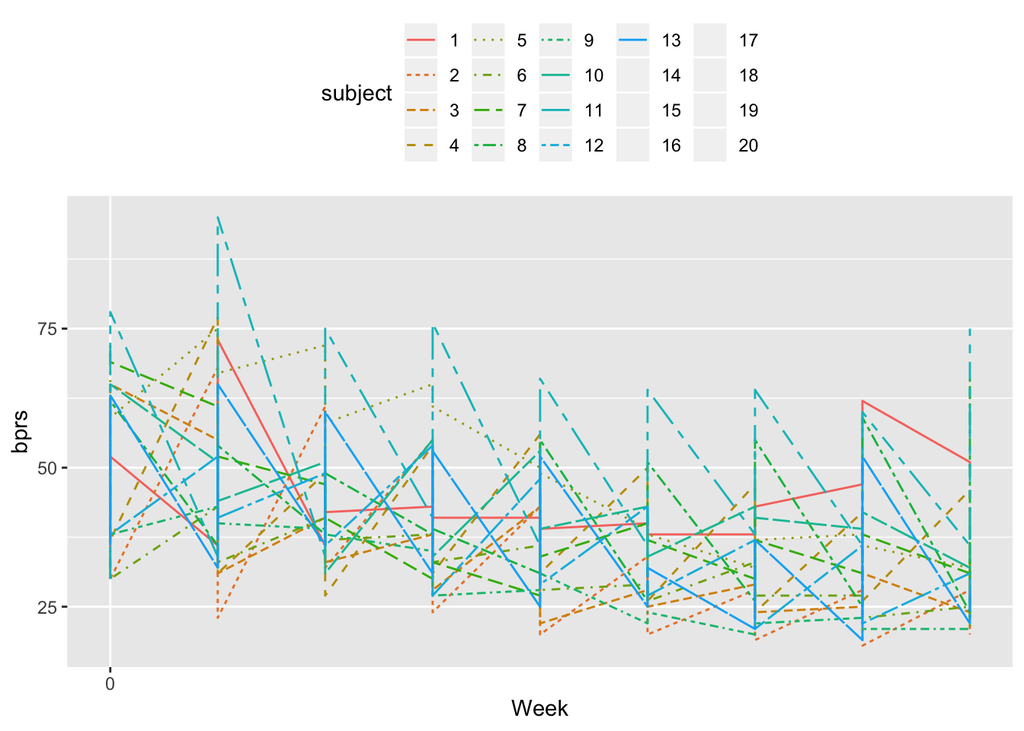

```r
ggplot(BPRS, aes(x = week, y = bprs, color = subject)) +
  geom_line(aes(linetype = subject)) +
  scale_x_continuous(name = "Week", breaks = seq(0, 60, 10)) +
  scale_y_continuous(name = "bprs") +
  theme(legend.position = "top")
```

Plotting the data for both treatment types:

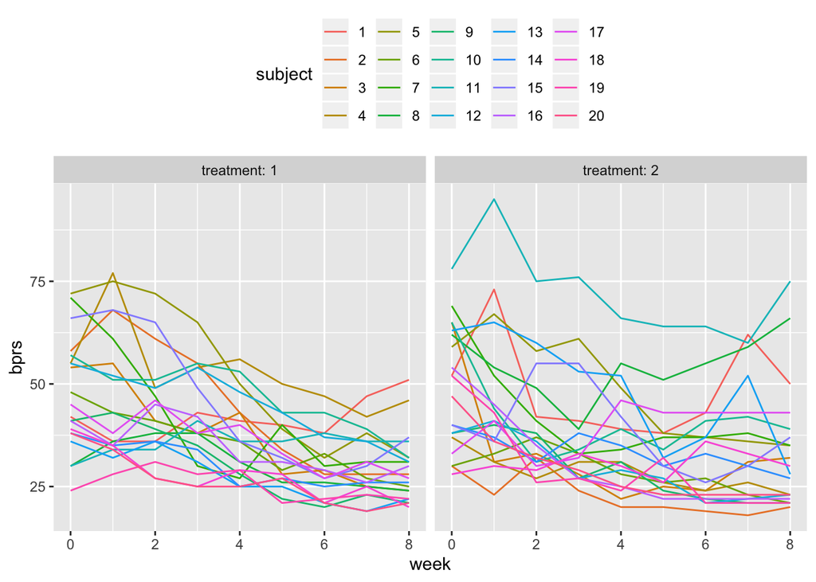

```r
ggplot(BPRS, aes(x = week, y = bprs, color=subject)) +
  geom_line() +
  scale_linetype_manual(values = rep(1:10, times=4)) +
  facet_grid(. ~ treatment, labeller = label_both) +
  theme(legend.position = "none") +
  scale_y_continuous(limits = c(min(BPRS$bprs), max(BPRS$bprs))) +
  theme(legend.position = "top")
```

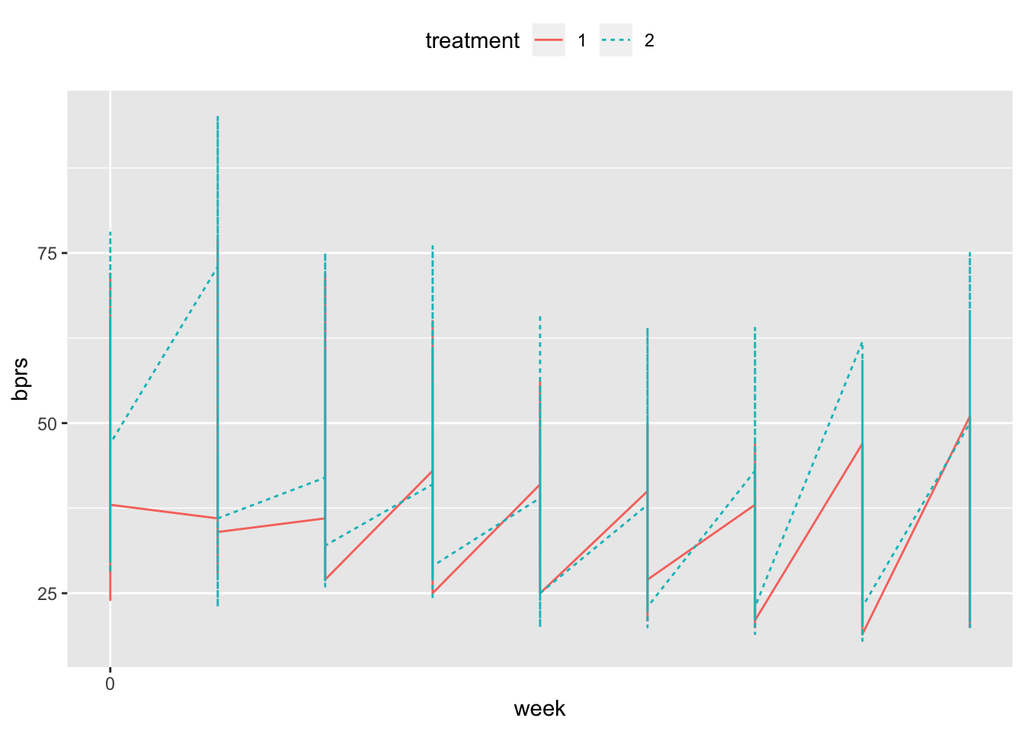

```r
ggplot(BPRS, aes(x = week, y = bprs, color = treatment)) +
  geom_line(aes(linetype = treatment)) +
  scale_x_continuous(name = "week", breaks = seq(0, 60, 20)) +
  scale_y_continuous(name = "bprs") +
  theme(legend.position = "top")
```

Using multiple regression model:

```r
BPRS_1 <- lm(bprs ~ week + treatment, data = BPRS)
summary(BPRS_1)
```

```
##
## Call:
## lm(formula = bprs ~ week + treatment, data = BPRS)
##
## Residuals:
##     Min      1Q  Median      3Q     Max
## -22.454  -8.965  -3.196   7.002  50.244
##
## Coefficients:
##             Estimate Std. Error t value Pr(>|t|)
## (Intercept)  46.4539     1.3670  33.982   <2e-16 ***
## week         -2.2704     0.2524  -8.995   <2e-16 ***
## treatment2    0.5722     1.3034   0.439    0.661
## ---
## Signif. codes:  0 '***' 0.001 '**' 0.01 '*' 0.05 '.' 0.1 ' ' 1
##
## Residual standard error: 12.37 on 357 degrees of freedom
## Multiple R-squared:  0.1851, Adjusted R-squared:  0.1806
## F-statistic: 40.55 on 2 and 357 DF,  p-value: < 2.2e-16
```

We can see that week number (time) is more significant than treatment type.

Using the random intercept model:

```r
BPRS_2 <- lmer(bprs ~ week + treatment + (1 | subject), data = BPRS, REML = FALSE)
summary(BPRS_2)
```

```
## Linear mixed model fit by maximum likelihood  ['lmerMod']
## Formula: bprs ~ week + treatment + (1 | subject)
##    Data: BPRS
##
##      AIC      BIC   logLik deviance df.resid
##   2748.7   2768.1  -1369.4   2738.7      355
##
## Scaled residuals:
##     Min      1Q  Median      3Q     Max
## -3.0481 -0.6749 -0.1361  0.4813  3.4855
##
## Random effects:
##  Groups   Name        Variance Std.Dev.
##  subject  (Intercept)  47.41    6.885
##  Residual             104.21   10.208
## Number of obs: 360, groups:  subject, 20
##
## Fixed effects:
##             Estimate Std. Error t value
## (Intercept)  46.4539     1.9090  24.334
## week         -2.2704     0.2084 -10.896
## treatment2    0.5722     1.0761   0.532
##
## Correlation of Fixed Effects:
##            (Intr) week
## week       -0.437
## treatment2 -0.282  0.000
```

The result shows that estimated variance of the random effects is really high. There are visible changes in values of treatment2 but are not significant.

Using the random intercept and random slope model:

```r
BPRS_3 <- lmer(bprs ~ week + treatment + (week | subject), data = BPRS, REML = FALSE)
summary(BPRS_3)
```

```
## Linear mixed model fit by maximum likelihood  ['lmerMod']
## Formula: bprs ~ week + treatment + (week | subject)
##    Data: BPRS
##
##      AIC      BIC   logLik deviance df.resid
##   2745.4   2772.6  -1365.7   2731.4      353
##
## Scaled residuals:
##     Min      1Q  Median      3Q     Max
## -2.8919 -0.6194 -0.0691  0.5531  3.7977
##
## Random effects:
##  Groups   Name        Variance Std.Dev. Corr
##  subject  (Intercept) 64.8222  8.0512
##           week         0.9609  0.9803   -0.51
##  Residual             97.4304  9.8707
## Number of obs: 360, groups:  subject, 20
##
## Fixed effects:
##             Estimate Std. Error t value
## (Intercept)  46.4539     2.1052  22.066
## week         -2.2704     0.2977  -7.626
## treatment2    0.5722     1.0405   0.550
##
## Correlation of Fixed Effects:
##            (Intr) week
## week       -0.582
## treatment2 -0.247  0.000
```

Using anova to compare models:

```r
anova(BPRS_3, BPRS_2)
```

```
## Data: BPRS
## Models:
## BPRS_2: bprs ~ week + treatment + (1 | subject)
## BPRS_3: bprs ~ week + treatment + (week | subject)
##        Df    AIC    BIC  logLik deviance  Chisq Chi Df Pr(>Chisq)
## BPRS_2  5 2748.7 2768.1 -1369.4   2738.7
## BPRS_3  7 2745.4 2772.6 -1365.7   2731.4 7.2721      2    0.02636 *
## ---
## Signif. codes:  0 '***' 0.001 '**' 0.01 '*' 0.05 '.' 0.1 ' ' 1
```